# Sustainable Urbanisation: Building Energy Consumption Forecast

16/11/2021

## Agenda

1. Introduction
2. Data exploration
3. Modelling process
4. Project ways of working
5. Further service opportunities

## Introduction

The project outlined here describes the high level project plan for a new digital service on the sustainable urbanisation business.

The service predicts short-term (up to 7 days ahead) energy demand for industrial business, based on the building characteristics, usage, and weather forecasts.

The service will be consumed by our customers through an API. We might also consider implementing a web-based UI, depending on customer feedback.

## Data exploration

1. Metadata, meter and weather data
2. Imputation and augmentation

## Data exploration: metadata

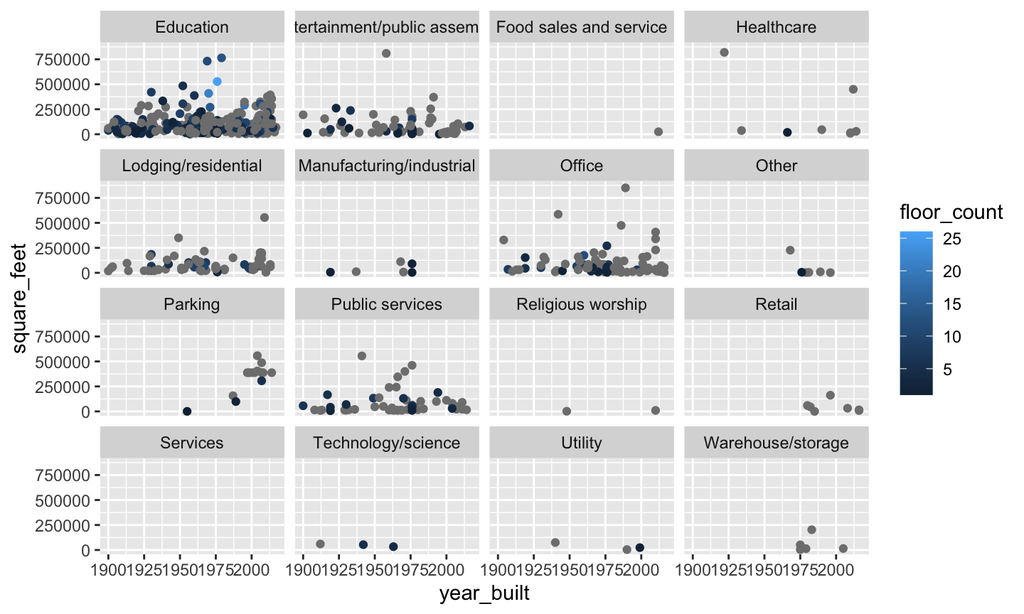

## Data exploration: metadata notes

- Missing data points
- Unbalanced dataset

Possible imputation:

1. Bin square_feet per primary_use, interpolate floor year_built
2. Bin square_feet and year_built per primary_use, interpolate floor_count

## Data exploration: meter readings

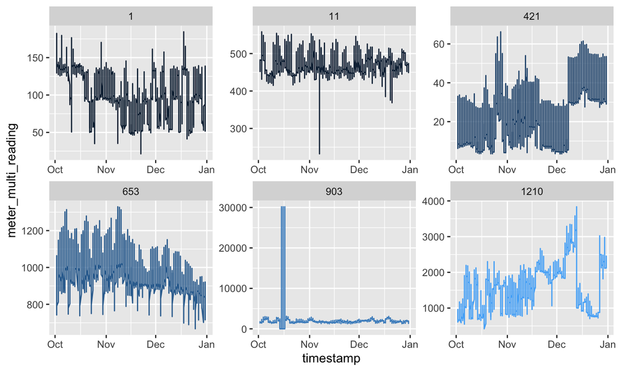

## Data exploration: meter readings notes

- No missing data on current dataset
- Scales varies significantly

Possible augmentation and imputation:

- Past consumption of own building and aggregate neighbourhood (sites)
- [STL decomposition](https://www.rdocumentation.org/packages/stats/versions/3.6.2/topics/stl)
- ARIMA to interpolate values (possibly leveraging [Kalman Filter (KF) approach](https://stats.stackexchange.com/questions/104565/how-to-use-auto-arima-to-impute-missing-values))

## Data exploration: weather data

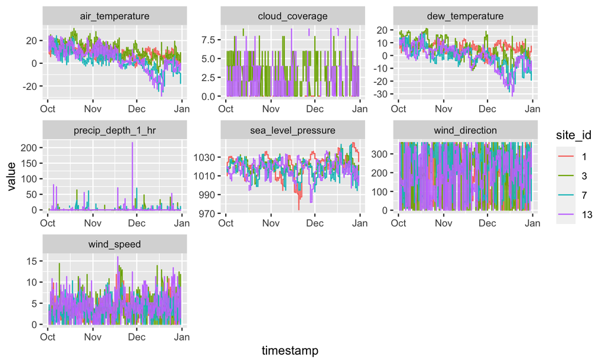

## Data exploration: weather data notes

- Missing data points

Possible augmentation and data imputation:

- Generally weather data can be augmented with engineering variables, lags and moving averages
- Similar to the meter data, STL decomposition or ARIMA + KF could be used for imputation
- Alternatively, if we have x,y coordinates for the site_id's we could also perform [kriging](https://en.wikipedia.org/wiki/Kriging)

## Modelling process

1. Data pre-processing
2. Model development

## Data pre-processing

1. Variables conversion
2. Outliers detection and treatment
3. Imputation process
4. Variable engineering (with SME)
5. Flat table generation

All steps substantiated with visualisations

## Model development

1. Train/test split (walk-forward)
2. Evaluate simpler model structures with larger subset of data
3. Setting aside a full-blind dataset is not required
4. Variable importance assessment (e.g. Boruta algorithm)
5. (OOS) metrics for benchmarking
6. Investigation plots (e.g. partial dependence plots, variable importance, etc.)
7. Model OOS metrics threshold is defined with SME for continued retraining and automation

## Ways of working

1. Delivery framework
2. Timelines
3. Architecture & controls
4. Operations pipeline

## Delivery framework

- Agile DevOps
- 4 eyes principle on each work package
- Required DevOps team skills: Business/SME, Data Science, MLOps
- Required support team skills: Scrum master/PM, IT Architecture and Information Risk Management (IRM)
- Steering committee should have representatives of all above disciplines
- When integration with external parties is required, those will be managed through SEI's CERT Resilience Management Model - [External Dependencies](https://resources.sei.cmu.edu/library/asset-view.cfm?assetid=514765)

## Timelines

- Sprints aiming at minor releases each sprint.
- First sprint workshop: business requirements followed by translation into high level design and controls' definition (Ops & IRM)
- Deliver working economical solution in 6 + 2 sprints
- By sprint 4 timelines will be re-negotiated

## Solution architecture & controls

- Cloud tool: Azure Machine Learning (AzureML)
- Environments: Development, Test and Production
- CICD pipelines maintained through GitHub actions
- Data workflow: Data will be sourced appropriately and stored as dataset connections, without effective interim storage (apart from models)
- Ops & IRM controls will be automatically monitored

## Operations (CICD) pipeline [1 of 2]

- Data tests will be defined and implemented
- Successful models will be converted into artefact for deployment
- Deployed artefacts will be exposed as endpoints on AzureML in the test environment

## Operations (CICD) pipeline [2 of 2]

- Optionally promotion of new model to production environment
- Model decay will be monitored and DevOps team will be notified when a significant improvement can be achieved by promoting a new model from test to production
- When model decay can not be treated with an available model on the test environment, DevOps team will be notified to act

## Further service opportunities

- With enough data gathered, by accessing energy price data, the service could be extended to predict local energy price
- Additional short term service: With energy price prediction, the service could send signal to automatically dispatch extra cooling/heating, for optimising the total energy cost
- Additional long term service: With long term data collected it is possible to suggest battery stack investments based on minimisation of energy costs in presence of storage

## Extras

All the material produced on this study is available in https://github.com/efsalvarenga/sustainableUrbanisation .

Original data received was not stored.